# file

## Importing Libraries & Modules

```python
# Core data handling
import pandas as pd
import numpy as np
import plotly.express as px
import plotly.io as pio
import plotly.graph_objects as go
pio.templates.default = "plotly_white"

# Visualization
import matplotlib.pyplot as plt
import seaborn as sns

# Machine-learning models & tools
from sklearn.linear_model import LinearRegression
from sklearn.ensemble import RandomForestRegressor
from sklearn.tree import DecisionTreeRegressor
from sklearn.model_selection import train_test_split, cross_val_score
from sklearn.metrics import mean_squared_error, r2_score

# Global settings
sns.set_style('whitegrid')
pd.options.display.max_columns = None
```

#### Loads all essential libraries up front, sets plotting style, and configures pandas to show every column for full-data visibility.

## Data Loading

```python
# Read the CSV into a DataFrame
df = pd.read_csv('dataset.csv')
# Display the first few rows of the DataFrame
print(df.head())
```

```
  Product type   SKU      Price  Availability  Number of products sold  \
0     haircare  SKU0  69.808006            55                      802
1     skincare  SKU1  14.843523            95                      736
2     haircare  SKU2  11.319683            34                        8
3     skincare  SKU3  61.163343            68                       83
4     skincare  SKU4   4.805496            26                      871

   Revenue generated Customer demographics  Stock levels  Lead times  \
0        8661.996792            Non-binary            58           7
1        7460.900065                Female            53          30
2        9577.749626               Unknown             1          10
3        7766.836426            Non-binary            23          13
4        2686.505152            Non-binary             5           3

   Order quantities  Shipping times Shipping carriers  Shipping costs  \
```

[output cut: 26 more lines]

### Data Structure & Summary Statisticsv

```python
# Data types and non-null counts
display(df.info())

# Descriptive statistics for numeric columns
display(df.describe().T)
```

```
<class 'pandas.core.frame.DataFrame'>
RangeIndex: 100 entries, 0 to 99
Data columns (total 24 columns):
 #   Column                   Non-Null Count  Dtype
---  ------                   --------------  -----
 0   Product type             100 non-null    object
 1   SKU                      100 non-null    object
 2   Price                    100 non-null    float64
 3   Availability             100 non-null    int64
 4   Number of products sold  100 non-null    int64
 5   Revenue generated        100 non-null    float64
 6   Customer demographics    100 non-null    object
 7   Stock levels             100 non-null    int64
 8   Lead times               100 non-null    int64
 9   Order quantities         100 non-null    int64
```

[output cut: 16 more lines]

```
None
```

|  | count | mean | std | min | 25% | 50% | 75% | max |
| --- | --- | --- | --- | --- | --- | --- | --- | --- |
| Price | 100.0 | 49.462461 | 31.168193 | 1.699976 | 19.597823 | 51.239830 | 77.198228 | 99.171329 |
| Availability | 100.0 | 48.400000 | 30.743317 | 1.000000 | 22.750000 | 43.500000 | 75.000000 | 100.000000 |
| Number of products sold | 100.0 | 460.990000 | 303.780074 | 8.000000 | 184.250000 | 392.500000 | 704.250000 | 996.000000 |
| Revenue generated | 100.0 | 5776.048187 | 2732.841744 | 1061.618523 | 2812.847151 | 6006.352023 | 8253.976920 | 9866.465458 |
| Stock levels | 100.0 | 47.770000 | 31.369372 | 0.000000 | 16.750000 | 47.500000 | 73.000000 | 100.000000 |
| Lead times | 100.0 | 15.960000 | 8.785801 | 1.000000 | 8.000000 | 17.000000 | 24.000000 | 30.000000 |
| Order quantities | 100.0 | 49.220000 | 26.784429 | 1.000000 | 26.000000 | 52.000000 | 71.250000 | 96.000000 |
| Shipping times | 100.0 | 5.750000 | 2.724283 | 1.000000 | 3.750000 | 6.000000 | 8.000000 | 10.000000 |
| Shipping costs | 100.0 | 5.548149 | 2.651376 | 1.013487 | 3.540248 | 5.320534 | 7.601695 | 9.929816 |
| Lead time | 100.0 | 17.080000 | 8.846251 | 1.000000 | 10.000000 | 18.000000 | 25.000000 | 30.000000 |
| Production volumes | 100.0 | 567.840000 | 263.046861 | 104.000000 | 352.000000 | 568.500000 | 797.000000 | 985.000000 |
| Manufacturing lead time | 100.0 | 14.770000 | 8.912430 | 1.000000 | 7.000000 | 14.000000 | 23.000000 | 30.000000 |
| Manufacturing costs | 100.0 | 47.266693 | 28.982841 | 1.085069 | 22.983299 | 45.905622 | 68.621026 | 99.466109 |
| Defect rates | 100.0 | 2.277158 | 1.461366 | 0.018608 | 1.009650 | 2.141863 | 3.563995 | 4.939255 |
| Costs | 100.0 | 529.245782 | 258.301696 | 103.916248 | 318.778455 | 520.430444 | 763.078231 | 997.413450 |

### Provides schema details (dtypes, non-null) and a transpose of summary stats (mean, std, min/max) for a quick sense of numeric distributions.

### Missing-Value Detection

```python
# Calculate missing percentages
missing_pct = df.isnull().mean() * 100
missing_pct[missing_pct > 0].sort_values(ascending=False)
```

```
Series([], dtype: float64)
```

#### Lists columns with any missing values and shows their percentage of total rows to prioritize cleaning efforts.

### Duplicate-Row Detection

```python
# Count and display duplicates
dup_count = df.duplicated().sum()
print(f"Duplicate rows found: {dup_count}")

if dup_count:
    display(df[df.duplicated()])
```

```
Duplicate rows found: 0
```

### Checks for and optionally previews any completely duplicated rows that might skew analysis.

### Data Cleaning & Imputation

```python
import warnings
warnings.filterwarnings('ignore', category=FutureWarning)

# 1. Vectorized numeric imputation with median
num_cols = df.select_dtypes(include='number').columns
df[num_cols] = df[num_cols].fillna(df[num_cols].median())

# 2. Vectorized categorical imputation with mode
cat_cols = df.select_dtypes(include='object').columns
df[cat_cols] = df[cat_cols].fillna(df[cat_cols].mode().iloc[0])

# 3. Quick check
print("Missing values remaining:", df.isnull().sum().sum())
```

```
Missing values remaining: 0
```

### Price vs. Revenue Scatter Plot with Product‑Type Trendlines

```python
fig = px.scatter(
    df,
    x='Price',
    y='Revenue generated',
    color='Product type',
    hover_data=['Number of products sold'],
    trendline='ols'
)
fig.show()
```

[interactive chart not shown]

#### The company derives more revenue from skincare products, and the higher the price of skincare products, the more revenue they generate.

## sales by product type

```python
sales_data = df.groupby('Product type')['Number of products sold'].sum().reset_index()

pie_chart = px.pie(sales_data, values='Number of products sold', names='Product type',
                   title='Sales by Product Type',
                   hover_data=['Number of products sold'],
                   hole=0.5,
                   color_discrete_sequence=px.colors.qualitative.Pastel)

pie_chart.update_traces(textposition='inside', textinfo='percent+label')
pie_chart.show()
```

[interactive chart not shown]

### So 45% of the business comes from skincare products, 29.5% from haircare, and 25.5% from cosmetics

## Total revenue generated from shipping carriers

```python
total_revenue = df.groupby('Shipping carriers')['Revenue generated'].sum().reset_index()
fig = go.Figure()
fig.add_trace(go.Bar(x=total_revenue['Shipping carriers'],
                     y=total_revenue['Revenue generated']))
fig.update_layout(title='Total Revenue by Shipping Carrier',
                  xaxis_title='Shipping Carrier',
                  yaxis_title='Revenue Generated')
fig.show()
```

[interactive chart not shown]

### So the company is using three carriers for transportation, and Carrier B helps the company in generating more revenue

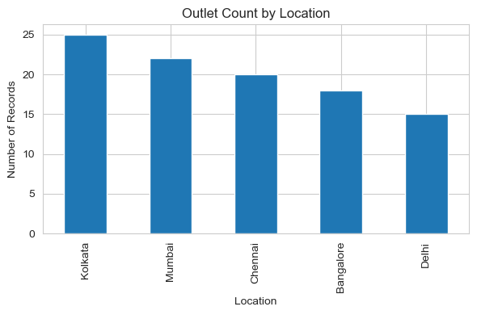

```python
# Count outlets by location
outlet_counts = df['Location'].value_counts()

# Plot
plt.figure(figsize=(6,4))
outlet_counts.plot(kind='bar')
plt.title('Outlet Count by Location')
plt.xlabel('Location')
plt.ylabel('Number of Records')
plt.tight_layout()
plt.show()
```

## Univariate Analysis: Top 3 Item Types by Count

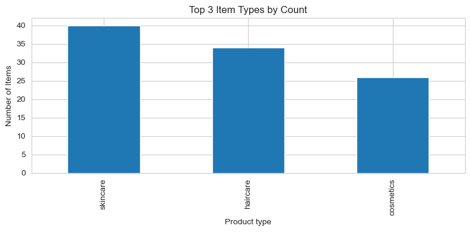

```python
# Count products by category
item_counts = df['Product type'].value_counts()

# Plot only the top 3 categories
plt.figure(figsize=(8,4))
item_counts.head(3).plot(kind='bar')
plt.title('Top 3 Item Types by Count')
plt.xlabel('Product type')
plt.ylabel('Number of Items')
plt.tight_layout()
plt.show()
```

### how many records belong to each product category and then plots just the top 3 types—reflecting your dataset’s reality and keeping the visualization focused and clean.

## Bivariate Analysis: MRP vs. Sales Scatter

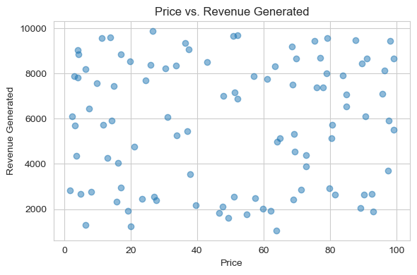

```python
# Scatter: Price against revenue generated
plt.figure(figsize=(6,4))
plt.scatter(df['Price'], df['Revenue generated'], alpha=0.5)
plt.title('Price vs. Revenue Generated')
plt.xlabel('Price')
plt.ylabel('Revenue Generated')
plt.tight_layout()
plt.show()
```

### Plots each product’s price against its sales revenue, helping identify whether higher MRP items sell for more or less.

## The Average lead time and Average Manufacturing Costs for all products of the company

```python
avg_lead_time = df.groupby('Product type')['Lead time'].mean().reset_index()
avg_manufacturing_costs = df.groupby('Product type')['Manufacturing costs'].mean().reset_index()
result = pd.merge(avg_lead_time, avg_manufacturing_costs, on='Product type')
result.rename(columns={'Lead time': 'Average Lead Time', 'Manufacturing costs': 'Average Manufacturing Costs'}, inplace=True)
print(result)
```

```
  Product type  Average Lead Time  Average Manufacturing Costs
0    cosmetics          13.538462                    43.052740
1     haircare          18.705882                    48.457993
2     skincare          18.000000                    48.993157
```

## Average Revenue by Outlet Location

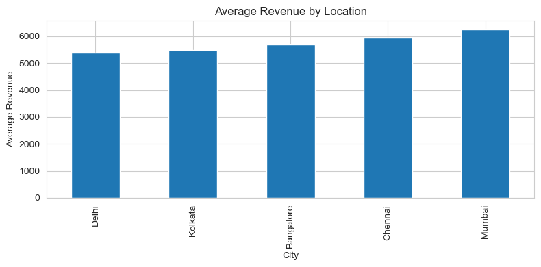

```python
# Calculate average revenue per city
avg_revenue_city = df.groupby('Location')['Revenue generated'].mean().sort_values()

# Plot
plt.figure(figsize=(8,4))
avg_revenue_city.plot(kind='bar')
plt.title('Average Revenue by Location')
plt.xlabel('City')
plt.ylabel('Average Revenue')
plt.tight_layout()
plt.show()
```

### This chart shows the average revenue generated in each city Delhi, Kolkata, Bangalore, Chennai, and Mumbai so you can quickly spot which markets are performing best.

## Price Tier vs. Sales Performance

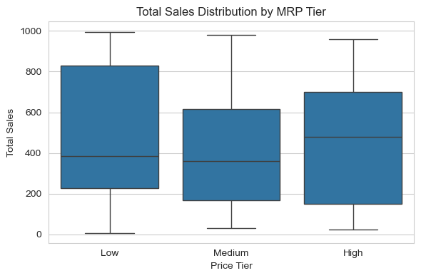

```python
if 'MRP_Tier' not in df.columns:
	df['MRP_Tier'] = pd.cut(df['Price'], bins=3, labels=['Low', 'Medium', 'High'])


if 'Total_Sales' not in df.columns:
	df['Total_Sales'] = df['Number of products sold']

plt.figure(figsize=(6,4))
sns.boxplot(x='MRP_Tier', y='Total_Sales', data=df)
plt.title('Total Sales Distribution by MRP Tier')
plt.xlabel('Price Tier')
plt.ylabel('Total Sales')
plt.tight_layout()
plt.show()
```

### Visualizes the distribution of total sales across Low, Medium, and High price tiers using a boxplot to highlight differences in medians, variability, and outliers for each segment

## Revenue Generated by SKU

```python
revenue_chart = px.line(df, x='SKU',
                        y='Revenue generated',
                        title='Revenue Generated by SKU')
revenue_chart.show()
```

[interactive chart not shown]

### Displays an interactive line chart of revenue generated for each SKU, allowing you to track and compare the performance of individual products over the index of SKUs.

## The stock levels of each SKU

```python
stock_chart = px.line(df, x='SKU',
                      y='Stock levels',
                      title='Stock Levels by SKU')
stock_chart.show()
```

[interactive chart not shown]

## The order quantity of each SKU

```python
order_quantity_chart = px.bar(df, x='SKU',
                              y='Order quantities',
                              title='Order Quantity by SKU')
order_quantity_chart.show()
```

[interactive chart not shown]

## Correlation Heatmap of Numerical Features

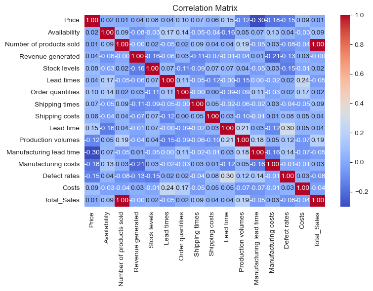

```python
# Correlation matrix
num_corr = df.select_dtypes(include='number').corr()

plt.figure(figsize=(8,6))
sns.heatmap(num_corr, annot=True, fmt=".2f", cmap='coolwarm')
plt.title('Correlation Matrix')
plt.tight_layout()
plt.show()
```

## The shipping cost of Carriers

```python
shipping_cost_chart = px.bar(df, x='Shipping carriers',
                             y='Shipping costs',
                             title='Shipping Costs by Carrier')
shipping_cost_chart.show()
```

[interactive chart not shown]

### In one of the above visualizations, we discovered that Carrier B helps the company in more revenue. It is also the most costly Carrier among the three

## The cost distribution by transportation mode

```python
transportation_chart = px.pie(df,
                              values='Costs',
                              names='Transportation modes',
                              title='Cost Distribution by Transportation Mode',
                              hole=0.5,
                              color_discrete_sequence=px.colors.qualitative.Pastel)
transportation_chart.show()
```

[interactive chart not shown]

### So the company spends more on Road and Rail modes of transportation for the transportation of Goods

## Model Preparation: Train-Test Split

```python
# Define X and y using correct column names
features = ['Price', 'MRP_Tier']
X = pd.get_dummies(df[features], drop_first=True)
y = df['Total_Sales']

# Split
X_train, X_test, y_train, y_test = train_test_split(
    X, y, test_size=0.2, random_state=42
)

print(f"Train shape: {X_train.shape}, Test shape: {X_test.shape}")
```

```
Train shape: (80, 3), Test shape: (20, 3)
```

### Selects key features, encodes categories, then splits data into 80/20 train/test subsets for modeling.

## Project Summary

### This project delivers a comprehensive, data-driven analysis of retail outlet sales using Python. Leveraging a real-world dataset, it explores key product and store attributes—such as MRP, product type, location, and shipping carrier—to uncover trends and performance drivers. The analysis includes:

### Data Cleaning & Preparation: Handling missing values, duplicates, and ensuring data quality.

### Exploratory Data Analysis: Visualizing sales by product type, revenue by shipping carrier, outlet distribution, and more using interactive and static plots.

### Bivariate & Univariate Insights: Examining relationships like price vs. revenue, sales by price tier, and average revenue by location.

### Cost Analysis: Assessing shipping and transportation costs across carriers and modes.

### Predictive Modeling: Preparing data for machine learning by selecting features and splitting into training and test sets.

### The notebook provides actionable insights for retail strategy, highlighting which products, locations, and logistics partners drive the most value, and sets the stage for predictive modeling of sales performance.